# Nonparametric Regression

Biostat 200C: kernel smoothers, splines, and local regression

Author

Dr. Jin Zhou @ UCLA

Published

May 26, 2026

Display system information and load `tidyverse` and `faraway` packages

```r
library(tidyverse)
library(faraway)
```

## 1 Parametric vs nonparametric models

- Given a regressor/predictor $x_1,\ldots,x_n$ and response $y_1, \ldots, y_n$, where
  $$y_i = f(x_i) + \epsilon_i,$$
  where $\epsilon_i$ are iid with mean zero and unknown variance $\sigma^2$.
- **Parametric approach** assumes that $f(x)$ belongs to a parametric family $f(x \mid \boldsymbol{\beta})$. Examples are
  $$\begin{eqnarray*}
  f(x \mid \boldsymbol{\beta}) &=& \beta_0 + \beta_1 x \\
  f(x \mid \boldsymbol{\beta}) &=& \beta_0 + \beta_1 x + \beta_2 x^2 \\
  f(x \mid \boldsymbol{\beta}) &=& \beta_0 + \beta_1 x^{\beta_2}.
  \end{eqnarray*}$$
- **Nonparametric approach** assumes $f$ is from some smooth family of functions.
- Nonparametric approaches offer flexible modelling of complex data, and often serve as valuable exploratory data analysis tools to guide formulation of meaningful and effective parametric models.
- Three running examples.
- `exa`: $f(x) = \sin^3 (2 \pi x^3)$.

```r
    exa <- as_tibble(exa) %>% print()
```

```
# A tibble: 256 × 3
        x       y     m
    <dbl>   <dbl> <dbl>
 1 0.0048 -0.0339     0
 2 0.0086  0.165      0
 3 0.0117  0.0245     0
 4 0.017   0.178      0
 5 0.0261 -0.347      0
 6 0.0299 -0.755      0
 7 0.0307  0.355      0
 8 0.0315  0.0401     0
 9 0.0331  0.106      0
10 0.034   0.122      0
# ℹ 246 more rows
```

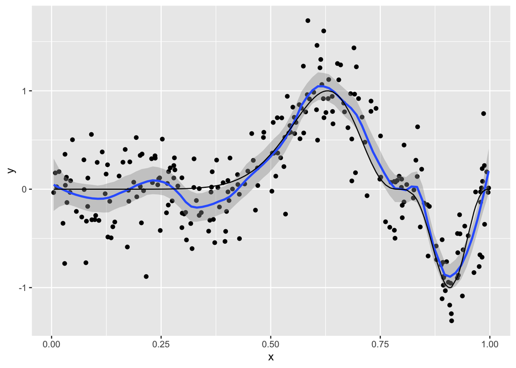

```r
    exa %>%
      ggplot(mapping = aes(x = x, y = y)) +
      geom_point() +
      geom_smooth(span = 0.2) + # small span give more wiggleness
      geom_line(mapping = aes(x = x, y = m)) # true model (black line)
```

- `exb`: $f(x) = 0$.

```r
    exb <- as_tibble(exb) %>% print()
```

```
# A tibble: 50 × 3
       x       y     m
   <dbl>   <dbl> <dbl>
 1  0.02  0.781      0
 2  0.04  1.64       0
 3  0.06 -0.363      0
 4  0.08 -0.0540     0
 5  0.1  -0.804      0
 6  0.12  0.907      0
 7  0.14 -0.843      0
 8  0.16 -0.229      0
 9  0.18 -0.499      0
10  0.2   1.20       0
# ℹ 40 more rows
```

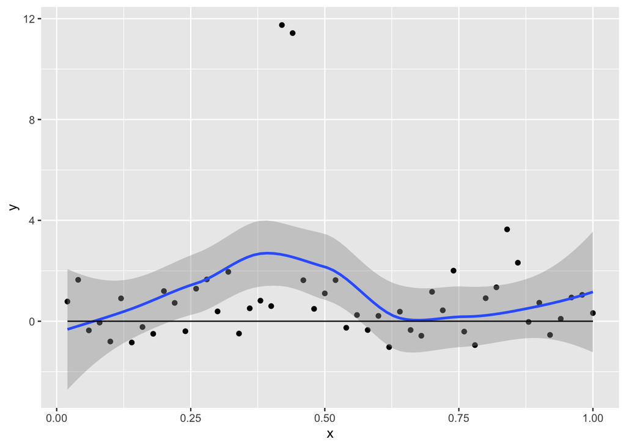

```r
    exb %>%
      ggplot(mapping = aes(x = x, y = y)) +
      geom_point() +
      geom_smooth() +
      geom_line(mapping = aes(x = x, y = m))
```

- `faithful`: data on Old Faithful geyser in Yellowstone National Park.

```r
    faithful <- as_tibble(faithful) %>% print()
```

```
# A tibble: 272 × 2
   eruptions waiting
       <dbl>   <dbl>
 1      3.6       79
 2      1.8       54
 3      3.33      74
 4      2.28      62
 5      4.53      85
 6      2.88      55
 7      4.7       88
 8      3.6       85
 9      1.95      51
10      4.35      85
# ℹ 262 more rows
```

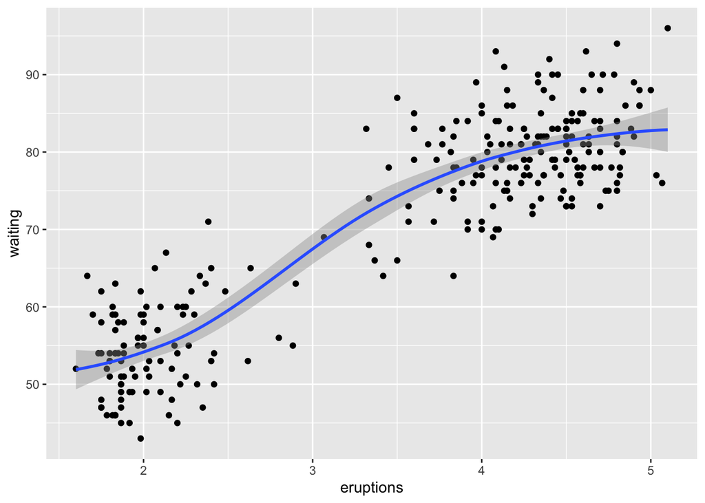

```r
    faithful %>%
      ggplot(mapping = aes(x = eruptions, y = waiting)) +
      geom_point() +
      geom_smooth() # small span give more wiggleness
```

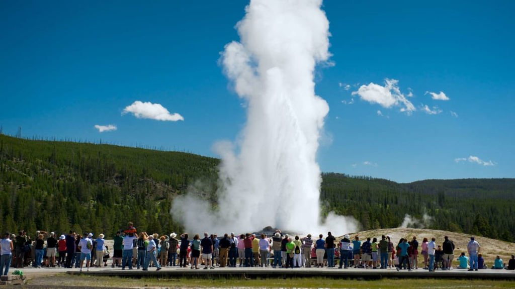

## 2 Kernel estimators

- [A conversation with Geoff Watson](https://projecteuclid.org/journals/statistical-science/volume-13/issue-1/A-conversation-with-Geoff-Watson/10.1214/ss/1028905975.full)
- Moving average estimator
  $$\hat f_\lambda(x) = \frac{1}{n\lambda} \sum_{j=1}^n K\left( \frac{x-x_j}{\lambda} \right) Y_j = \frac{1}{n} \sum_{j=1}^n w_j Y_j,$$
  where
  $$w_j = \lambda^{-1} K\left( \frac{x-x_j}{\lambda} \right),$$
  and $K$ is a **kernel** such that $\int K(x) \, dx = 1$. $\lambda$ is called the **bandwidth**, **window width** or **smoothing parameter**.
- When $x$s are spaced unevenly, the kernel estimator can give poor results. This is improved by the **Nadaraya-Watson** estimator
  $$f_\lambda(x) = \frac{\sum_{j=1}^n w_j Y_j}{\sum_{j=1}^n w_j}.$$
- Asymptotics of kernel estimators
  $$\text{MSE}(x) = \mathbb{E} [f(x) - \hat f_\lambda(x)]^2 = O(n^{-4/5}).$$
  Typical parametric estimator has $\text{MSE}(x) = O(n^{-1})$ *if the parametric model is correct*.
- Choice of kernel. Ideal kernel is smooth, compact, and amenable to rapid computation. The optimal choice under some standard assumptions is the **Epanechnikov kernel**
  $$K(x) = \begin{cases}
  \frac 34 (1 - x^2) & |x| < 1 \\
  0 & \text{otherwise}
  \end{cases}.$$

[figure not shown]

- Choice of smoothing parameter $\lambda$. Small $\lambda$ gives more wiggly curves, while large $\lambda$ yields smoother curves.

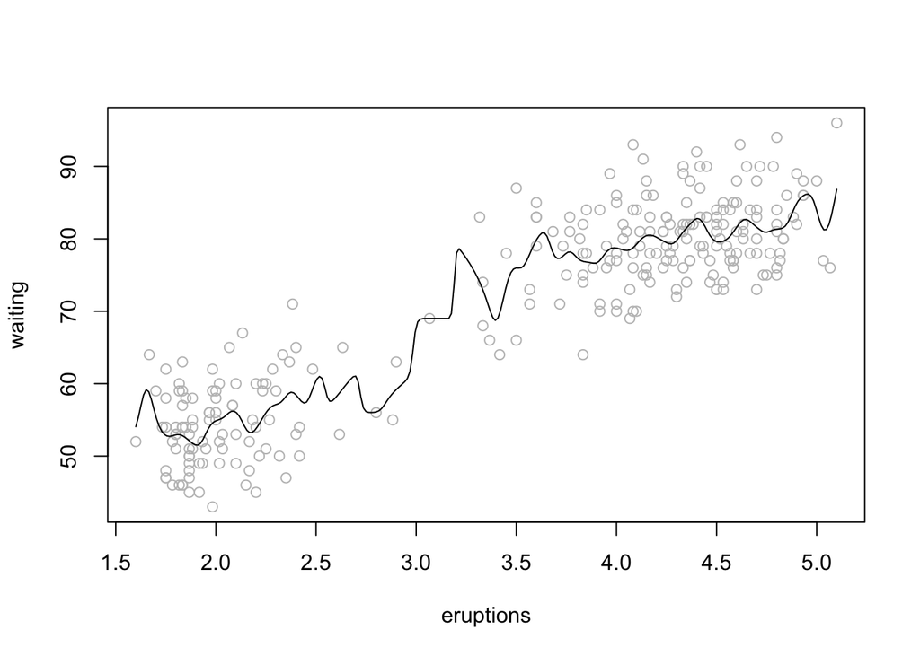

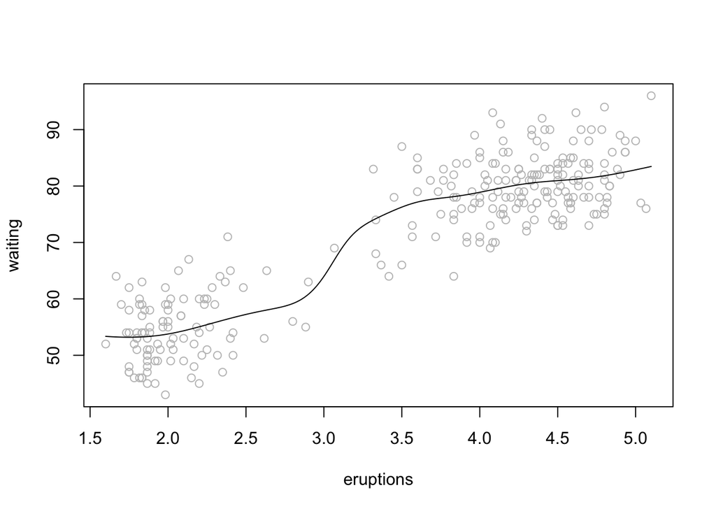

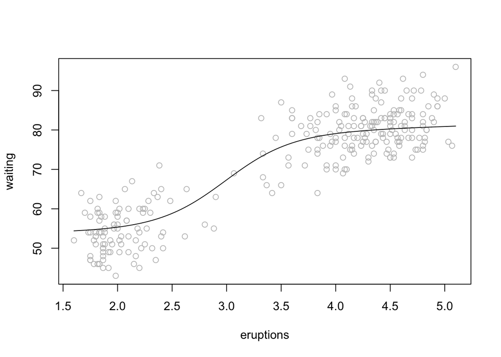

```r
for (bw in c(0.1, 0.5, 2)) {
  with(faithful, {
    plot(waiting ~ eruptions, col = gray(0.75))
    # Nadaraya–Watson kernel estimate with normal kernel
    lines(ksmooth(eruptions, waiting, "normal", bw))
  })
}
```

- Cross-validation (CV) choose the $\lambda$ that minimizes the criterion
  $$\text{CV}(\lambda) = \frac 1n \sum_{j=1}^n [y_j - \hat f_{\lambda(j)}(x_j)]^2,$$
  where $(j)$ indicates that point $j$ is left out of the fit.

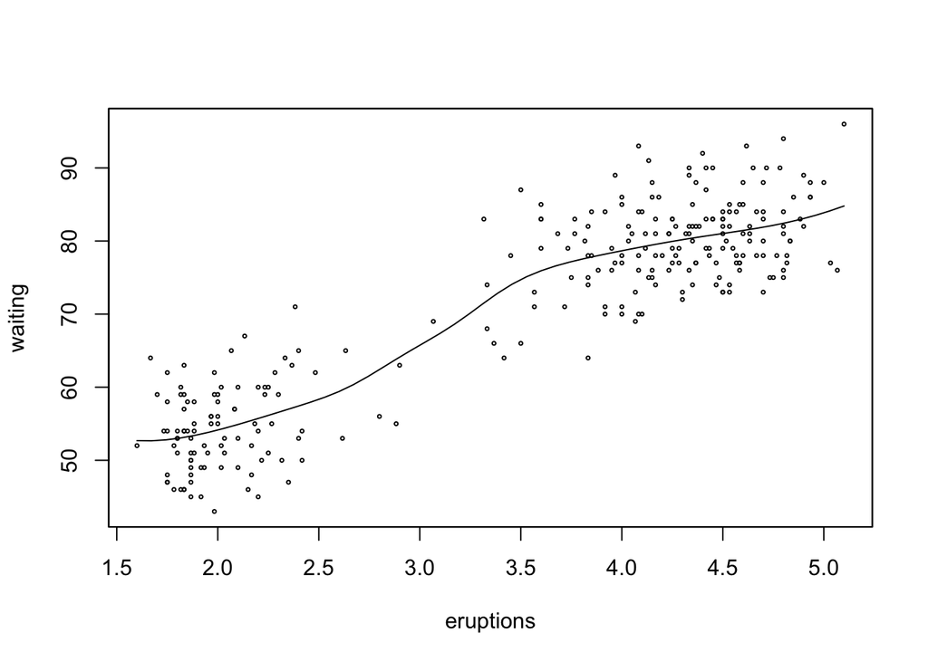

```r
library(sm)

with(faithful,
     sm.regression(eruptions, waiting, h = h.select(eruptions, waiting)))
```

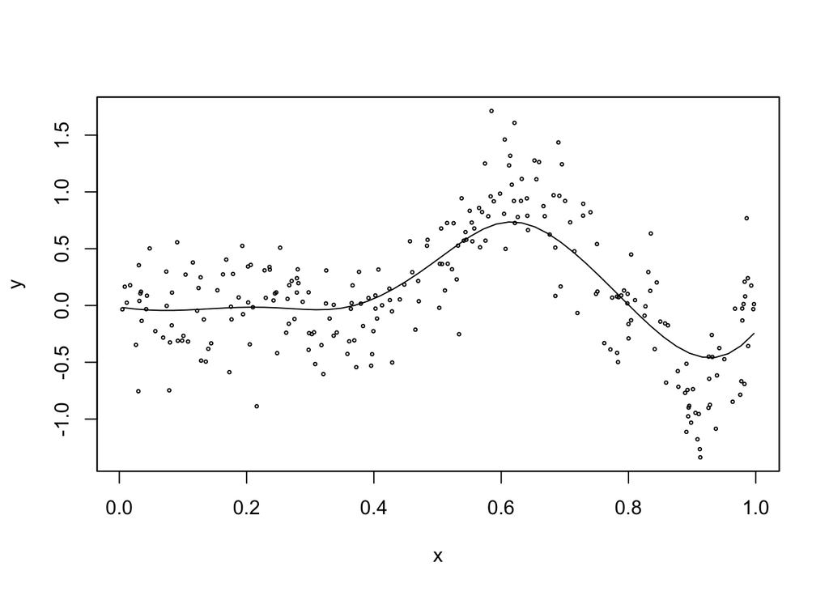

```r
with(exa, sm.regression(x, y, h = h.select(x, y)))
```

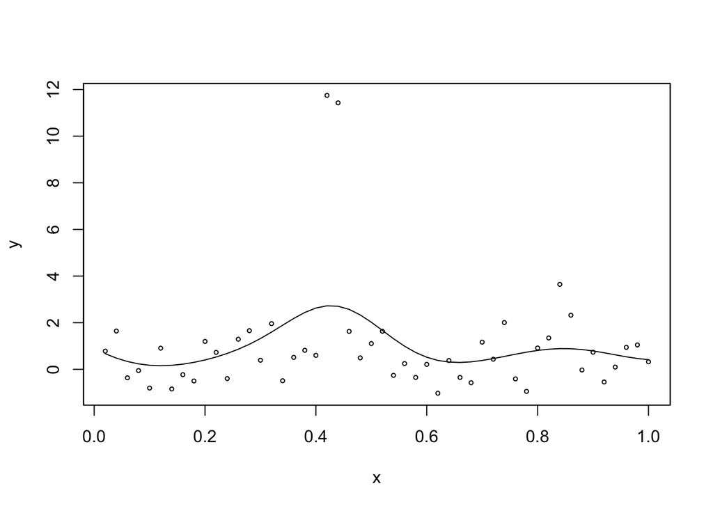

```r
with(exb, sm.regression(x, y, h = h.select(x, y)))
```

## 3 Splines

- [A Conversation with Grace Wahba](https://projecteuclid.org/journals/statistical-science/volume-35/issue-2/A-Conversation-with-Grace-Wahba/10.1214/19-STS734.full)

### 3.1 Why Splines?

- Kernel smoothers and local averaging are intuitive, but they can be hard to write as familiar regression models.
- Splines keep the flexibility of nonparametric regression while using the familiar linear-model form
  $$\hat f(x) = \sum_{m=1}^M \hat\beta_m h_m(x).$$
- Once the basis functions $h_m$ are chosen, estimation is ordinary least squares or penalized least squares.
- Main teaching question: **where does smoothness come from?**

### 3.2 Piecewise Polynomials

- Instead of using one polynomial over the whole range of $x$, fit different polynomials in regions separated by **knots**.
- For example, a piecewise cubic polynomial with one knot at $c$ takes the form
  $$y_i =
  \begin{cases}
  \beta_{01} + \beta_{11}x_i + \beta_{21}x_i^2 + \beta_{31}x_i^3 + \epsilon_i, & x_i < c, \\
  \beta_{02} + \beta_{12}x_i + \beta_{22}x_i^2 + \beta_{32}x_i^3 + \epsilon_i, & x_i \geq c.
  \end{cases}$$
- Without constraints, the fitted curve can jump or bend sharply at the knots.
- Splines add continuity constraints. Cubic splines are continuous and have continuous first and second derivatives.

[figure not shown]

### 3.3 Linear Splines

- A **linear spline** with knots at $\xi_k$, $k = 1,\ldots,K$, is a piecewise linear function that is continuous at each knot.
- A convenient basis is
  $$y_i = \beta_0 + \beta_1 x_i + \sum_{k=1}^K \beta_{k+1}(x_i-\xi_k)_+ + \epsilon_i,$$
  where
  $$(x_i-\xi_k)_+ =
  \begin{cases}
  x_i-\xi_k, & x_i > \xi_k, \\
  0, & \text{otherwise}.
  \end{cases}$$

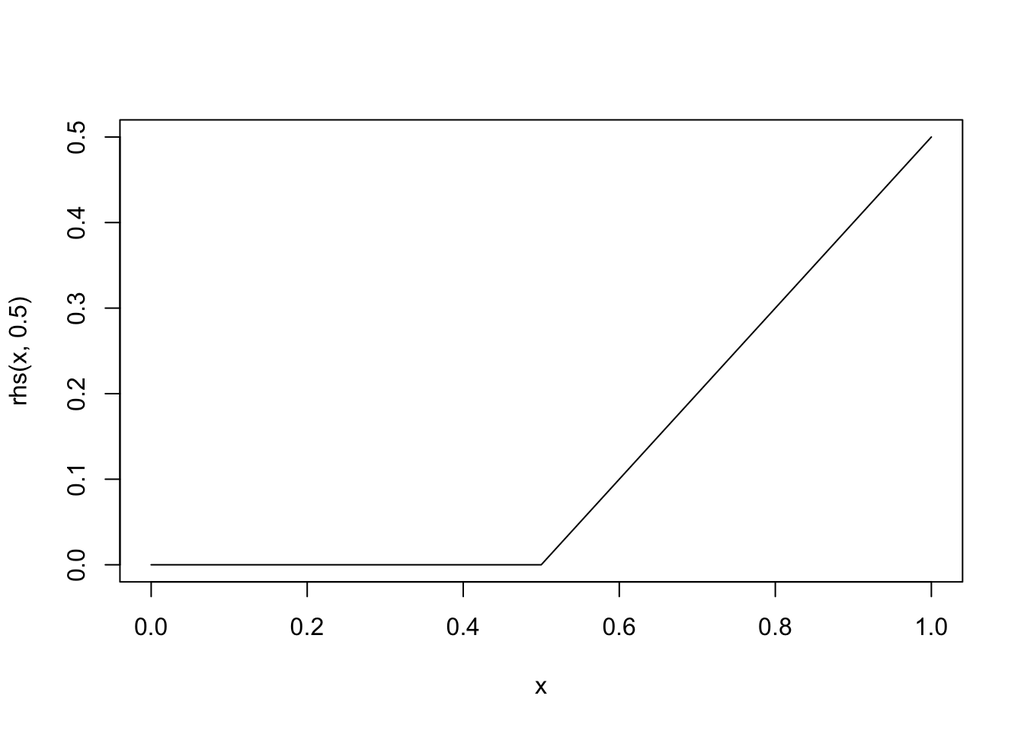

```r
# right hockey stick function (RHS) with a knot at c
rhs <- function(x, c) ifelse(x > c, x - c, 0)
curve(rhs(x, 0.5), 0, 1)
```

- The basis functions look like “hinges”; each knot allows the slope to change after that point.

```r
(knots <- 0:9 / 10)
```

```
 [1] 0.0 0.1 0.2 0.3 0.4 0.5 0.6 0.7 0.8 0.9
```

```r
dm <- outer(exa$x, knots, rhs)
dim(dm)
```

```
[1] 256  10
```

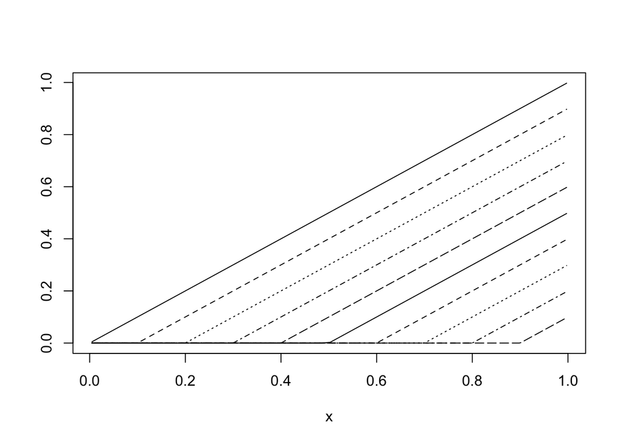

```r
matplot(exa$x, dm, type = "l", col = 1, xlab = "x", ylab="")
```

### 3.4 Regression Splines

- A **regression spline** uses a relatively small set of knots, then estimates the basis coefficients by regression.
- With fixed knots, spline fitting is just linear regression on the constructed basis functions.

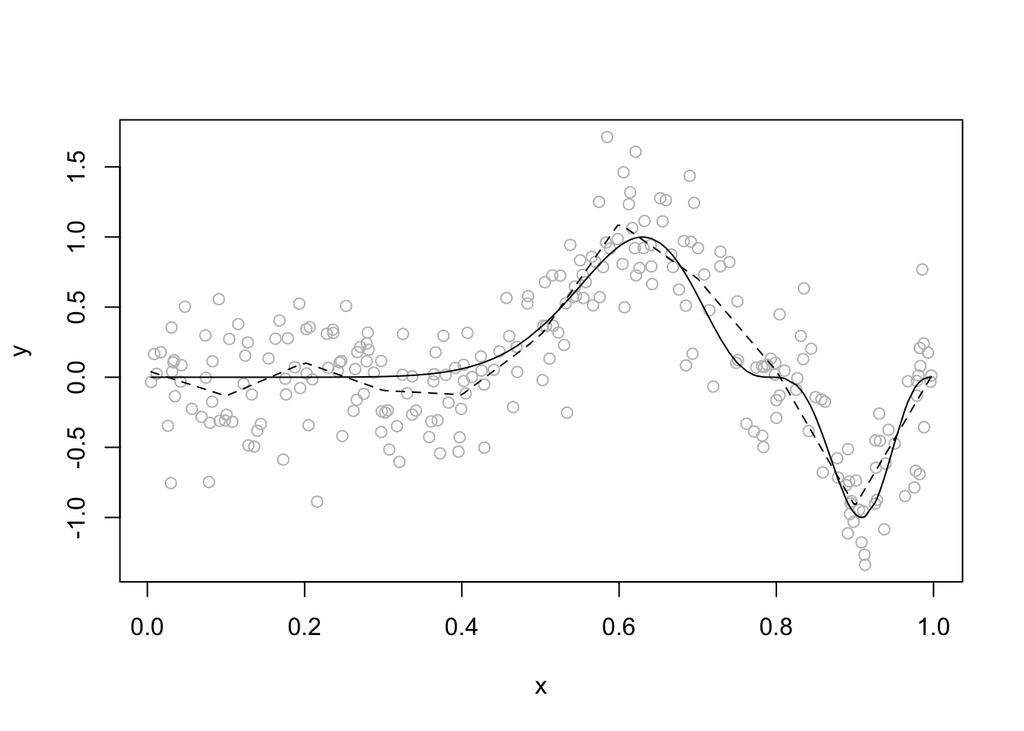

```r
lmod <- lm(exa$y ~ dm)
plot(y ~ x, exa, col = gray(0.75))
lines(m ~ x, exa)
lines(exa$x, predict(lmod), lty = 2)
```

- Better knot placement can improve the fit: use more knots where the function has more curvature.

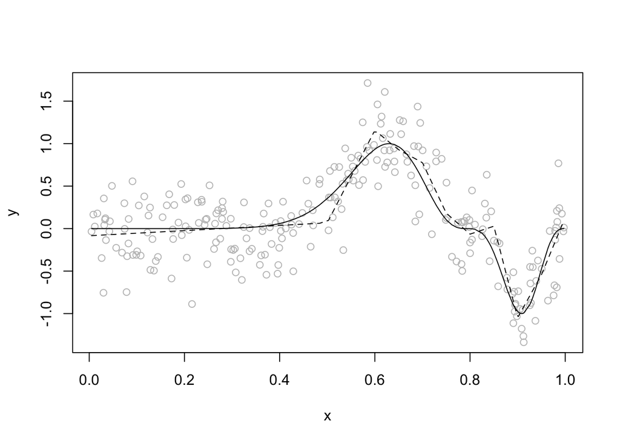

```r
newknots <- c(0, 0.5, 0.6, 0.65, 0.7, 0.75, 0.8, 0.85, 0.9, 0.95)
dmn <- outer(exa$x, newknots, rhs)
lmod <- lm(exa$y ~ dmn)
plot(y ~ x, data = exa, col = gray(0.75))
lines(m ~ x, exa)
lines(exa$x, predict(lmod), lty = 2)
```

### 3.5 Cubic Splines and B-Splines

- A **cubic spline** with knots at $\xi_k$, $k = 1,\ldots,K$, is a piecewise cubic polynomial with continuous derivatives up to order 2 at each knot.
- One basis is the truncated power basis:
  $$1,\ x,\ x^2,\ x^3,\ (x-\xi_1)_+^3,\ldots,(x-\xi_K)_+^3.$$
- The truncated power basis is conceptually simple, but can be numerically unstable. In practice, software usually uses **B-splines**, which are stable and locally supported.

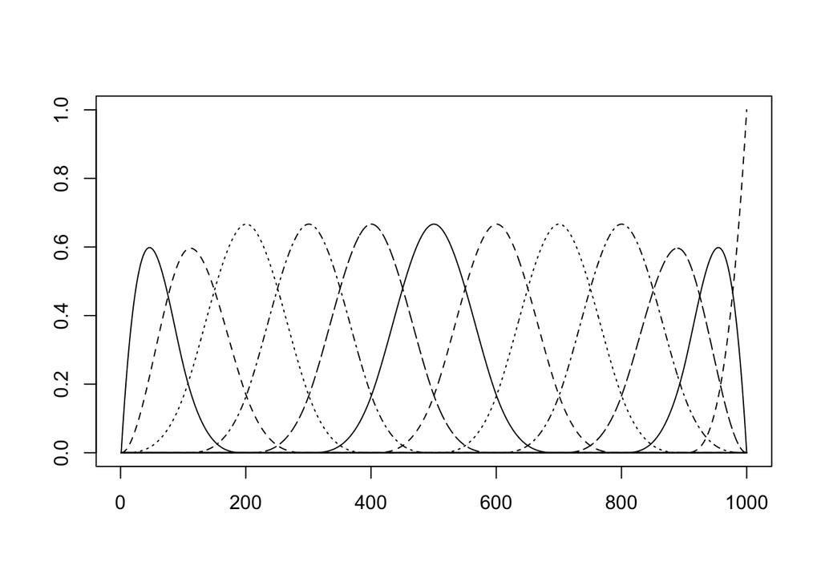

```r
library(splines)

matplot(bs(seq(0, 1, length = 1000), df = 12), type = "l", ylab="", col = 1)
```

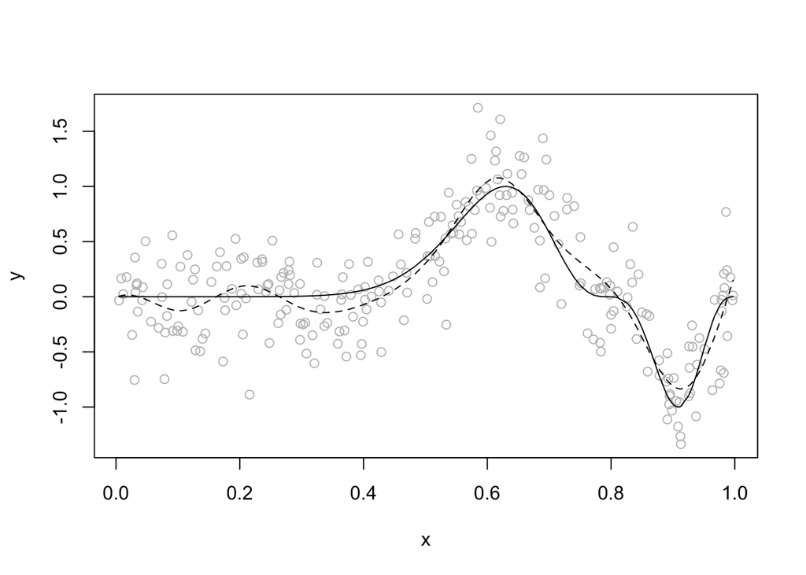

```r
# generate design matrix using B-splines with df = 12
lmod <- lm(y ~ bs(x, df = 12), exa)
plot(y ~ x, exa, col = gray(0.75))
lines(m ~ x, exa) # true model
lines(predict(lmod) ~ x, exa, lty = 2) # Cubic B-spline fit
```

### 3.6 Natural Cubic Splines

- Regular splines can have high variance near the boundary of the observed $x$ range.
- A **natural cubic spline** is constrained to be linear beyond the boundary knots.
- This reduces unstable tail behavior while allowing flexible curvature in the middle of the data.

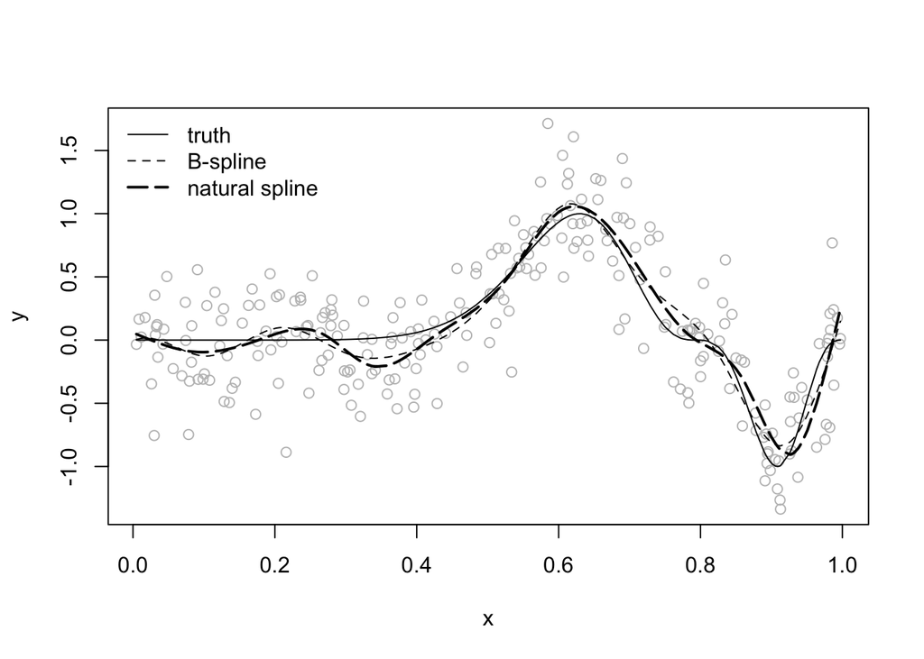

```r
lmod_bs <- lm(y ~ bs(x, df = 12), exa)
lmod_ns <- lm(y ~ ns(x, df = 12), exa)

plot(y ~ x, exa, col = gray(0.75))
lines(m ~ x, exa)
lines(predict(lmod_bs) ~ x, exa, lty = 2)
lines(predict(lmod_ns) ~ x, exa, lty = 5, lwd = 2)
legend(
  "topleft",
  legend = c("truth", "B-spline", "natural spline"),
  lty = c(1, 2, 5),
  lwd = c(1, 1, 2),
  bty = "n"
)
```

- In practice, users often specify the degrees of freedom and let software choose knot number and placement.

### 3.7 Smoothing Splines

- A smoothing spline chooses $\hat f$ to minimize the penalized least-squares criterion
  $$\frac 1n \sum_i [y_i - f(x_i)]^2 + \lambda \int [f''(x)]^2 \, dx,$$
  where $\lambda > 0$ is the **smoothing parameter** and $\int [f''(x)]^2 \, dx$ is a **roughness penalty**.
- Large $\lambda$ gives a smoother curve; small $\lambda$ gives a more flexible curve.
- As $\lambda \to \infty$, the fit approaches a straight line. When $\lambda = 0$, the fit interpolates the data.
- The minimizer is a natural cubic spline with knots at the unique observed $x_i$ values.

### 3.8 Effective Degrees of Freedom

- The fitted values can be written as
  $$\hat{\mathbf f}_\lambda = S_\lambda \mathbf y,$$
  where $S_\lambda$ is the smoothing matrix.
- The **effective degrees of freedom** are
  $$\mathrm{df}_\lambda = \sum_i S_{\lambda, ii}.$$
- This lets software report or tune smoothing splines using `df`, even though the optimization is controlled by $\lambda$.
- Leave-one-out cross-validation can be computed efficiently as
  $$\text{CV}(\lambda)
  = \sum_{i=1}^n
  \left[
  \frac{y_i - \hat f_\lambda(x_i)}{1 - S_{\lambda, ii}}
  \right]^2.$$

### 3.9 Smoothing Spline Examples

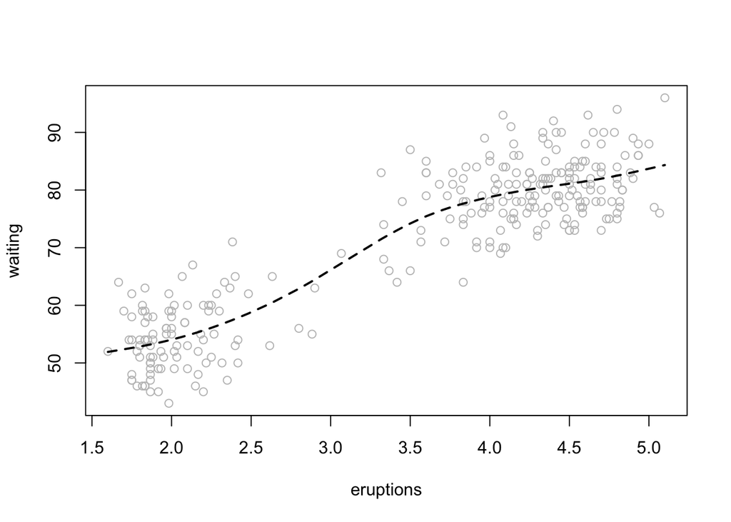

```r
with(faithful, {
  plot(waiting ~ eruptions, col = gray(0.75))
  lines(smooth.spline(eruptions, waiting), lty = 2, lwd = 2)
})
```

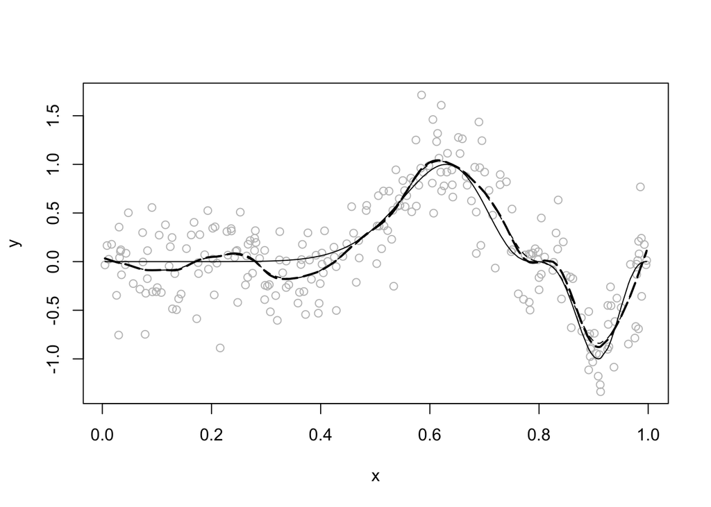

```r
with(exa, {
  plot(y ~ x, col = gray(0.75))
  lines(x, m) # true model
  lines(smooth.spline(x, y, df = 16), lty = 2)
  lines(smooth.spline(x, y, cv = TRUE), lty = 5, lwd = 2)
})
```

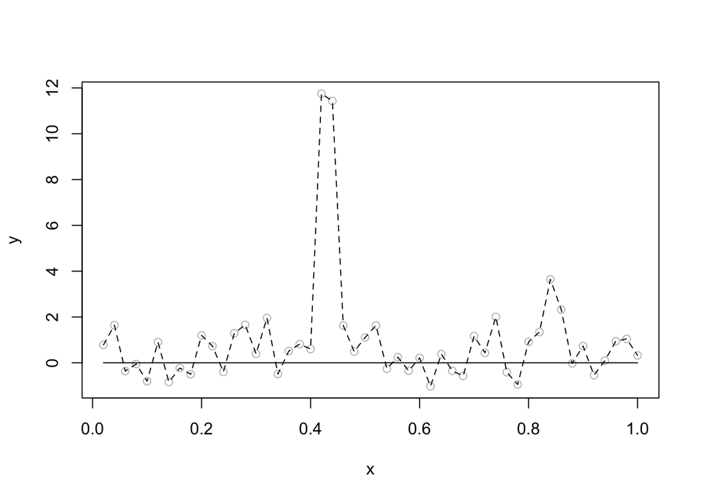

```r
with(exb, {
  plot(y ~ x, col = gray(0.75))
  lines(x, m) # true model
  lines(smooth.spline(x, y), lty = 2)
})
```

- The `exb` example is useful pedagogically: automatic tuning is helpful, but it is not foolproof.

### 3.10 Regression vs Smoothing Splines

- **Regression splines**: choose a smaller set of knots; fit by regression on spline basis functions.
- **Smoothing splines**: use knots at all unique observed $x_i$ values; control wiggliness with a penalty.
- Same family of smooth functions, different strategy for controlling complexity.

## 4 Local Polynomial Regression

[figure not shown]

- Both kernel and spline smoothers are vulnerable to outliers.
- **Local polynomial** methods fit a polynomial in a moving window, then use the fitted value at the center of the window as the estimate. This procedure is repeated over the range of the data.
- **lowess** (locally weighted scatterplot smoothing) or **loess** (locally estimated scatterplot smoothing) functions in R.
- We choose the polynomial order and window width. In R, `loess()` defaults to a quadratic local fit with span 0.75.
- Examples.

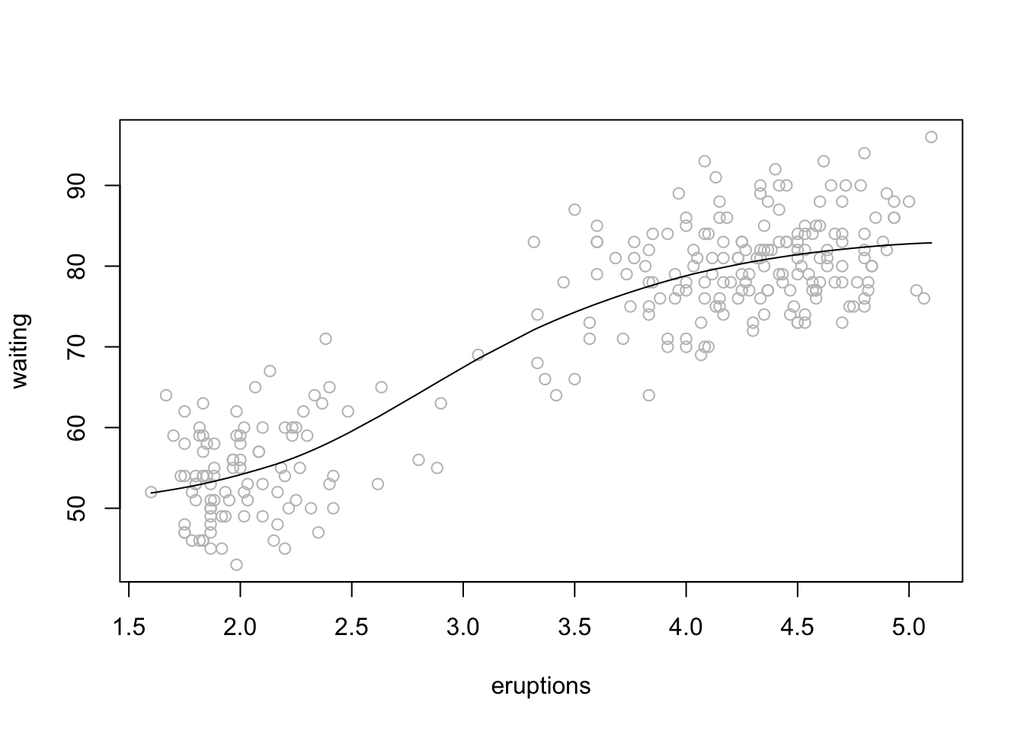

```r
with(faithful, {
  plot(waiting ~ eruptions, col = gray(0.75))
  f <- loess(waiting ~ eruptions)
  i <- order(eruptions)
  lines(f$x[i], f$fitted[i])
})
```

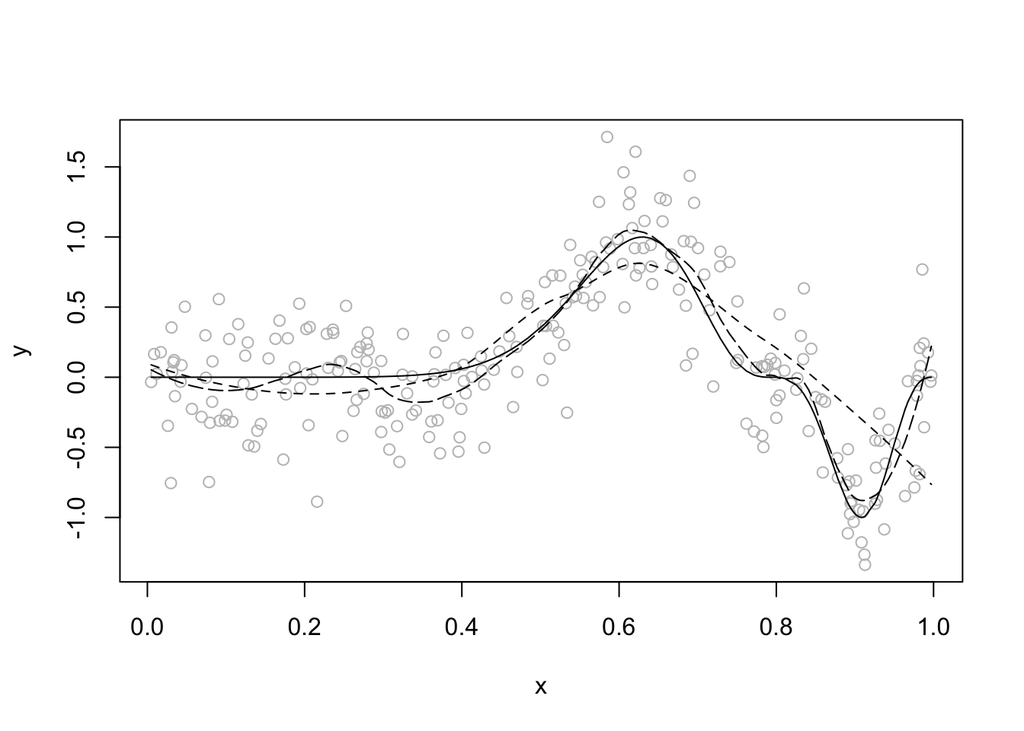

```r
with(exa, {
  plot(y ~ x, col = gray(0.75))
  lines(m ~ x)
  f <- loess(y ~ x) # default span = 0.75
  lines(f$x, f$fitted, lty = 2)
  # try smaller span (proportion of the range)
  f <- loess(y ~ x, span = 0.22)
  lines(f$x, f$fitted, lty = 5)
})
```

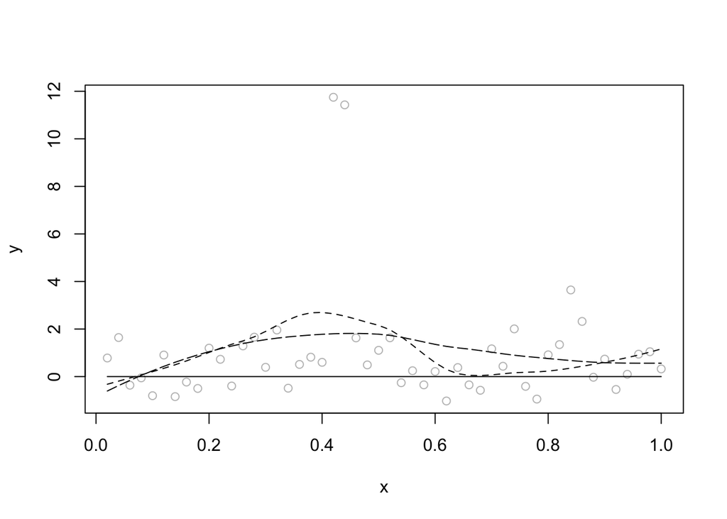

```r
with(exb, {
  plot(y ~ x, col = gray(0.75))
  lines(m ~ x)
  f <- loess(y ~ x) # default span = 0.75
  lines(f$x, f$fitted, lty = 2)
  # span = 1 means whole span of data (smoothest)
  f <- loess(y ~ x, span = 1)
  lines(f$x, f$fitted, lty = 5)
})
```

- Pointwise confidence band is obtained by the local parametric fit for smoothing splines or loess.

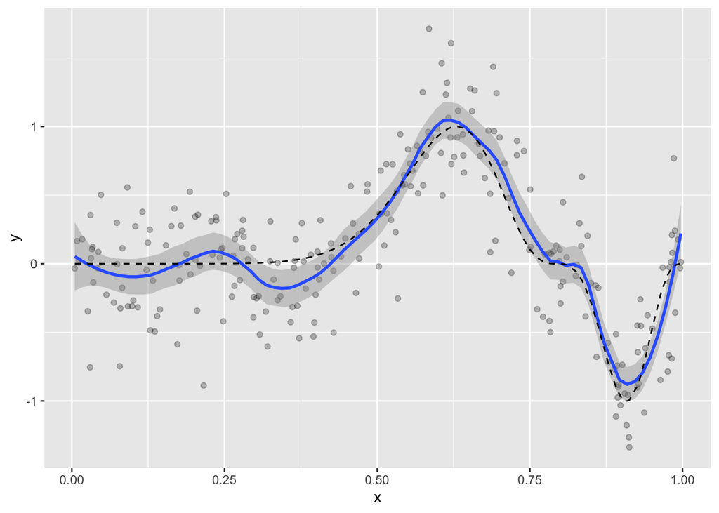

```r
ggplot(data = exa, mapping = aes(x = x, y = y)) +
  geom_point(alpha = 0.25) +
  geom_smooth(method = "loess", span = 0.22) +
  geom_line(mapping = aes(x = x, y = m), linetype = 2)
```

- Simultaneous confidence band can be constructed by the `mgcv` package.

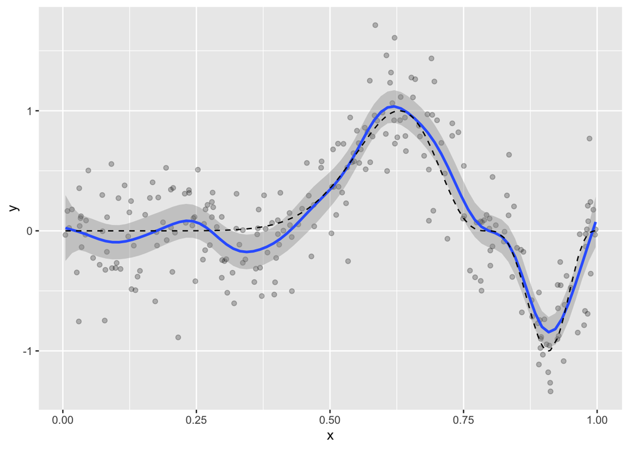

```r
library(mgcv)

ggplot(data = exa, mapping = aes(x = x, y = y)) +
  geom_point(alpha = 0.25) +
  geom_smooth(method = "gam", span = 0.22, formula = y ~ s(x, k = 20)) +
  geom_line(mapping = aes(x = x, y = m), linetype = 2)
```

## 5 Takeaways

- Nonparametric regression trades a strict parametric form for a smoothness assumption.
- Kernel methods average nearby observations; the bandwidth controls smoothness.
- Regression splines use a small basis expansion and fit by ordinary regression.
- Smoothing splines use many knots but penalize curvature; $\lambda$ or effective degrees of freedom controls smoothness.
- Local polynomial regression fits simple models locally; the span controls how local the fit is.
- In applied work, the most important habit is to vary the smoothness and check whether the substantive story changes.

## 6 Optional: Wavelets

- In general, we approximate a curve by a family of basis functions
  $$\hat f(x) = \sum_i c_i \phi_i(x),$$
  where the basis functions $\phi_i$ are given and the coefficients $c_i$ are estimated.
- Ideally we would like the basis functions $\phi_i$ to be compactly supported, so they adapt to local features, and orthogonal, so computation is fast.
- Orthogonal polynomials and Fourier basis are not compactly supported.
- Cubic B-splines are compactly supported but not orthogonal.
- **Wavelets** can be both compactly supported and orthogonal.
- **Haar basis**. The mother wavelet function on [0, 1]
  $$w(x) = \begin{cases}
  1 & x \le 1/2 \\
  -1 & x > 1/2
  \end{cases}.$$
  Next two members are defined on [0, 1/2) and [1/2, 1) by rescaling the mother wavelet to these two intervals. In general, at level $j$
  $$h_n(x) = 2^{j/2} w(2^j x - k),$$
  where $n = 2^j + k$ and $0 \le k \le 2^j$.